# Business Industries and Job Titles Across MH, CCB, and NHF (DAT-589)

Andrew Lin

2024-05-15

# Modern Healthcare

## Businesses Industries

There are currently 14909 distinct active individual MH customers, of which 6439 customers have a business description of other, unknown, Comp-Misc, or Comp-Sample.Ignoring the unknown individuals, the top 10 business industry distribution is as follows:

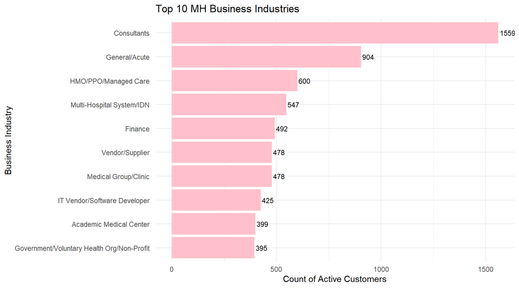

| Business Industry | Active Customers | Total Subscribers | Share of Total Customers |
| --- | --- | --- | --- |
| Other Healthcare Organization | 6439 | 14909 | 43.19 |
| Consultants | 1559 | 14909 | 10.46 |
| General/Acute | 904 | 14909 | 6.06 |
| HMO/PPO/Managed Care | 600 | 14909 | 4.02 |
| Multi-Hospital System/IDN | 547 | 14909 | 3.67 |
| Finance | 492 | 14909 | 3.30 |
| Medical Group/Clinic | 478 | 14909 | 3.21 |
| Vendor/Supplier | 478 | 14909 | 3.21 |
| IT Vendor/Software Developer | 425 | 14909 | 2.85 |
| Academic Medical Center | 399 | 14909 | 2.68 |

## Job Titles

With regards to Job Titles, around 7887 have missing or other job titles. CEOs and other higher-level executives tend to make up the larger portion of subscriber jobs.

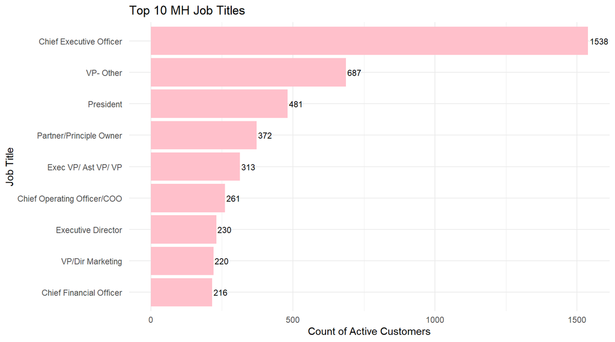

| Job Title | Active Customers | Total Subscribers | Share of Total Customers |
| --- | --- | --- | --- |
| Other hospital/healthcare executives not listed above | 7887 | 14909 | 52.90 |
| Chief Executive Officer | 1538 | 14909 | 10.32 |
| VP- Other | 687 | 14909 | 4.61 |
| President | 481 | 14909 | 3.23 |
| Partner/Principle Owner | 372 | 14909 | 2.50 |
| Exec VP/ Ast VP/ VP | 313 | 14909 | 2.10 |
| Chief Operating Officer/COO | 261 | 14909 | 1.75 |
| Executive Director | 230 | 14909 | 1.54 |
| VP/Dir Marketing | 220 | 14909 | 1.48 |
| Chief Financial Officer | 216 | 14909 | 1.45 |

## Job Positions by Business

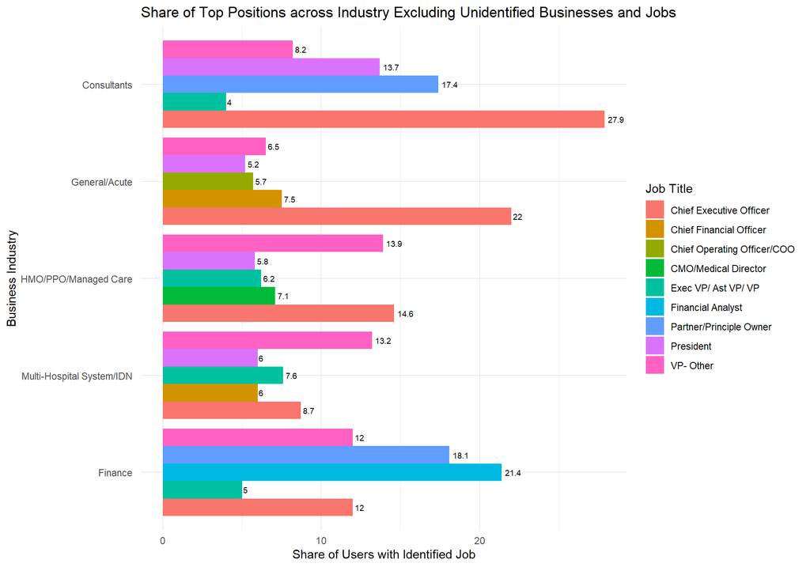

# CCB Health Pulse

## Business Industries

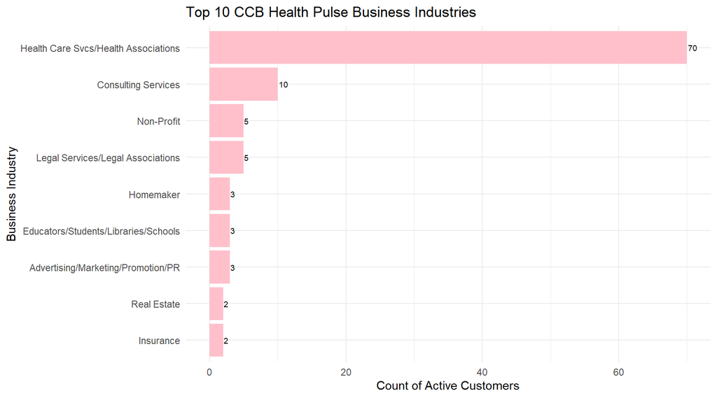

| Business Industry | Active Customers | Total Subscribers | Share of Total Customers |
| --- | --- | --- | --- |
| Others Allied to the Field | 380 | 493 | 77.08 |
| Health Care Svcs/Health Associations | 70 | 493 | 14.20 |
| Consulting Services | 10 | 493 | 2.03 |
| Legal Services/Legal Associations | 5 | 493 | 1.01 |
| Non-Profit | 5 | 493 | 1.01 |
| Advertising/Marketing/Promotion/PR | 3 | 493 | 0.61 |
| Educators/Students/Libraries/Schools | 3 | 493 | 0.61 |
| Homemaker | 3 | 493 | 0.61 |
| Insurance | 2 | 493 | 0.41 |
| Real Estate | 2 | 493 | 0.41 |

## Job Titles

Out of 493 active , 386 do not have a job title or are categorized as unknown. The remaining job titles are distributed as such:

| Job Title | Active Customers | Total Subscribers | Share of Total Customers |
| --- | --- | --- | --- |
| Misc titles including Government | 386 | 493 | 78.30 |
| Chairman/Pres/COO/CEO/Partner | 34 | 493 | 6.90 |
| Exec VP/Sr VP/GM/Vice Chairman/Executive Directors | 20 | 493 | 4.06 |
| Managers/Directors/Coordinators | 16 | 493 | 3.25 |
| All other VP/Corp Directors and Managers/Managing Directors | 13 | 493 | 2.64 |
| Professionals - Attorneys/Engineers/Architects/Editors/Consultants/etc.) | 12 | 493 | 2.43 |
| All Sales Directors/Sales Managers/Account Managers | 4 | 493 | 0.81 |
| CFO/Treasurer/Controller/CPA | 4 | 493 | 0.81 |
| Assistants to title code 40 | 2 | 493 | 0.41 |
| Assistants to title above 01 | 1 | 493 | 0.20 |
| Assistants to title code 20 | 1 | 493 | 0.20 |

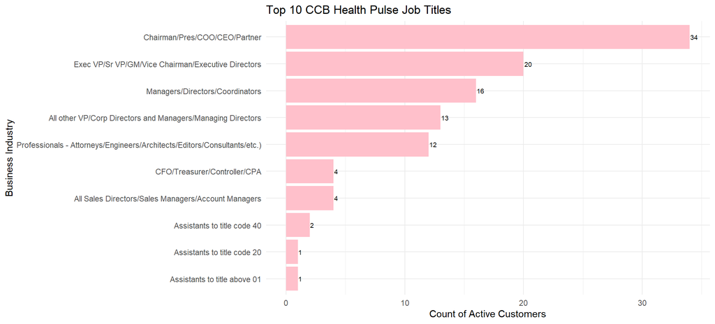

# Jobs Positions by Business

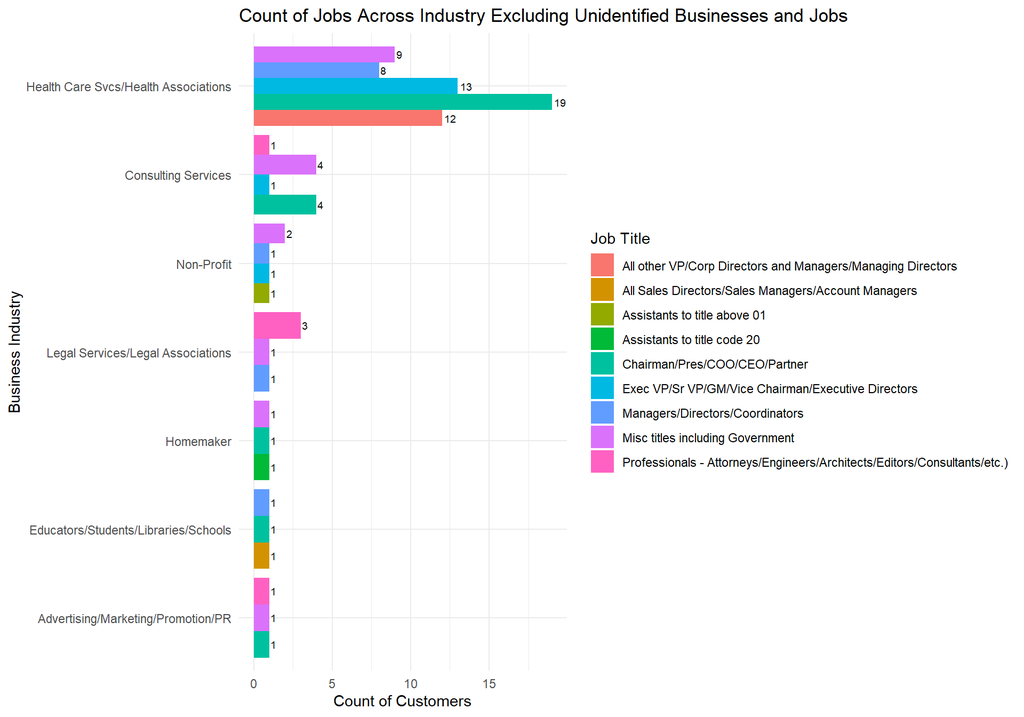

# CNY Healthpulse

## Business Industries

Out of 955 active users, 105 are categorized as unknown wrt their business industry. The remaining distribution follows:

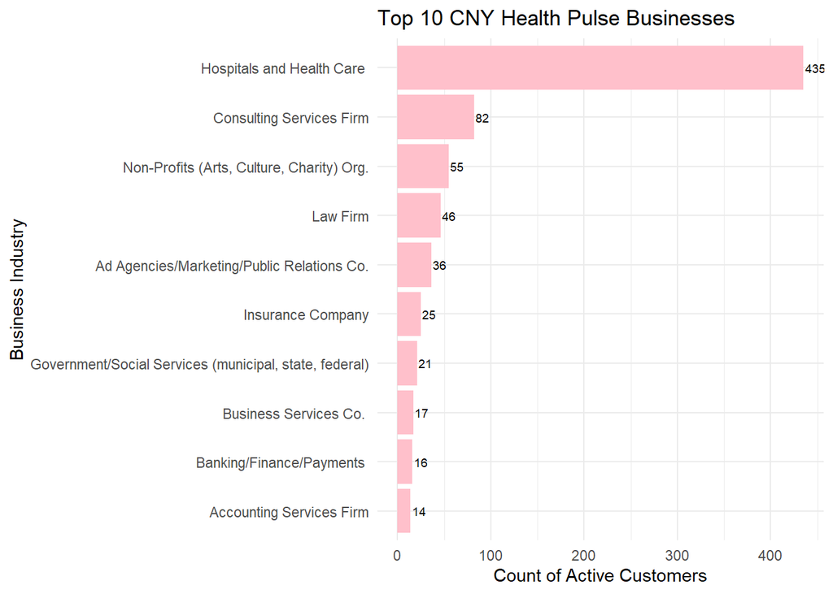

| Business Industry | Active Customers | Total Subscribers | Share of Total Customers |
| --- | --- | --- | --- |
| Hospitals and Health Care | 435 | 955 | 45.55 |
| Other | 105 | 955 | 10.99 |
| Consulting Services Firm | 82 | 955 | 8.59 |
| Non-Profits (Arts, Culture, Charity) Org. | 55 | 955 | 5.76 |
| Law Firm | 46 | 955 | 4.82 |
| Ad Agencies/Marketing/Public Relations Co. | 36 | 955 | 3.77 |
| Insurance Company | 25 | 955 | 2.62 |
| Government/Social Services (municipal, state, federal) | 21 | 955 | 2.20 |
| Business Services Co. | 17 | 955 | 1.78 |
| Banking/Finance/Payments | 16 | 955 | 1.68 |

## Job Titles

Around 667 of those active users do not have information regarding their job title. The others follow this distribution:

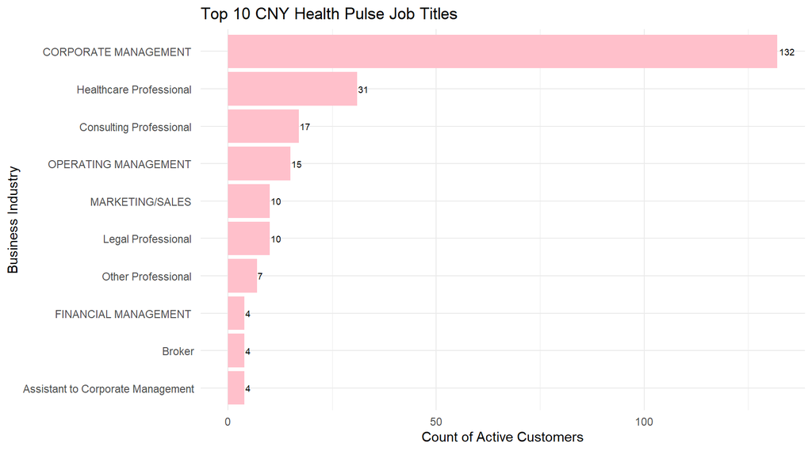

| Job Title | Active Customers | Total Subscribers | Share of Total Customers |
| --- | --- | --- | --- |
| Unknown | 667 | 955 | 69.84 |
| CORPORATE MANAGEMENT | 132 | 955 | 13.82 |
| Other Miscellaneous Titles | 42 | 955 | 4.40 |
| Healthcare Professional | 31 | 955 | 3.25 |
| Consulting Professional | 17 | 955 | 1.78 |
| OPERATING MANAGEMENT | 15 | 955 | 1.57 |
| Legal Professional | 10 | 955 | 1.05 |
| MARKETING/SALES | 10 | 955 | 1.05 |
| Other Professional | 7 | 955 | 0.73 |
| Assistant to Corporate Management | 4 | 955 | 0.42 |
| Broker | 4 | 955 | 0.42 |
| FINANCIAL MANAGEMENT | 4 | 955 | 0.42 |

## Job Positions by Business

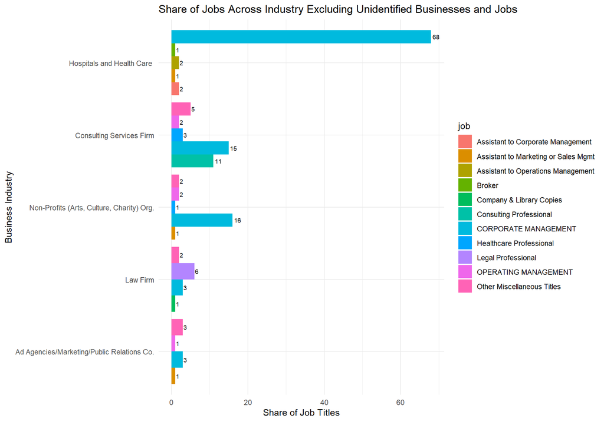

# Share of active and identified (non-other / Unknown Job Title) Job Titles across Publication

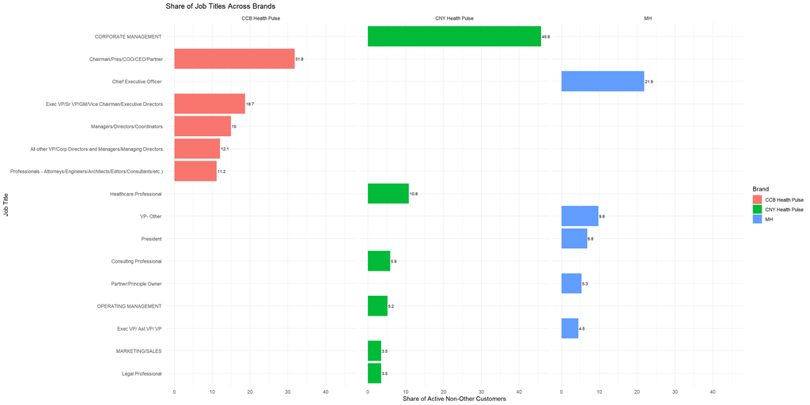

# Share of active and identified (non-other / Unknown Business Industries) Business Industries across Publication

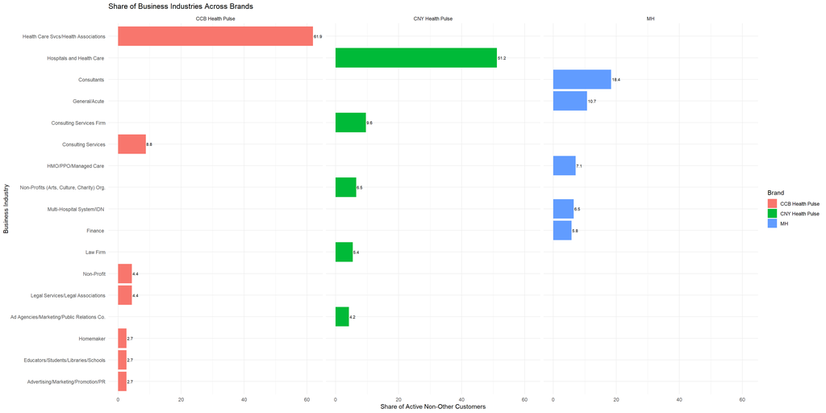

# Concluding Thoughts

While a majority of MH, CCB, and NHF subscribers had missing or unknown job titles, it’s clear that across brands, higher-level positions like CEO, President, etc. tend to make up the largest proportion of non-missing job titles. In fact, outside of CNY Health Pulse, no other brand has healthcare professional as a listed job title.

MH, CCB Health Pulse, and NHF both have high proportions of users that work in a healthcare-related organization. Furthermore, consultant-related industries appear to occupy a substantial portion for all three brands as well. Other than those similarities, CCB and NHF splinters off with non-health related industries while MH is still focused on health-related industries. When choosing to offer discounts or trials for MH, it’s clear that targeting NHF and CCB Health Pulse individuals that belong to upper manage and work within a consultation or hospital related organization may provide a higher chance of success.